# HW 2: Visualization, Base R

Data 180, Professor Kennedy

Tommy Eaton

eatont@dickinson.edu

October 10, 2023

Make sure that you have accepted the hw invitation link, and working with your clone repository.

**Due date:** September 28 beginning of class.

**Reminder:** You can insert R code in your Rmd file as a chunk in the following way:

```r
# Your code goes here
```

Make sure to insert a chunk for each (sub)section of the assignment.

**Theme of the assignment**: Let’s practice visualization using base R and create cool maps. Load in the `Cars93` dataset by running the following code chunk:

```r
library(MASS)
data(Cars93)
```

The library function will load and attach add-on packages that have been previously installed on your machine. This will give you access to the functions and datasets available in the package. In general, you only need to install a package once (although it may require updating from time to time) but you need to access it using the library command every time you start a new session in R (and want the functionality).

The questions below use the `Cars93` data frame as a source of data. This data frame is part of the MASS package and becomes available after loading it. You can get a view of the top of the data frame by using the head command. For more information, type `?Cars93`. Let’s load `Cars93` in,

```r
head(Cars93)
```

```
##   Manufacturer   Model    Type Min.Price Price Max.Price MPG.city MPG.highway
## 1        Acura Integra   Small      12.9  15.9      18.8       25          31
## 2        Acura  Legend Midsize      29.2  33.9      38.7       18          25
## 3         Audi      90 Compact      25.9  29.1      32.3       20          26
## 4         Audi     100 Midsize      30.8  37.7      44.6       19          26
## 5          BMW    535i Midsize      23.7  30.0      36.2       22          30
## 6        Buick Century Midsize      14.2  15.7      17.3       22          31
##              AirBags DriveTrain Cylinders EngineSize Horsepower  RPM
## 1               None      Front         4        1.8        140 6300
## 2 Driver & Passenger      Front         6        3.2        200 5500
## 3        Driver only      Front         6        2.8        172 5500
## 4 Driver & Passenger      Front         6        2.8        172 5500
## 5        Driver only       Rear         4        3.5        208 5700
## 6        Driver only      Front         4        2.2        110 5200
##   Rev.per.mile Man.trans.avail Fuel.tank.capacity Passengers Length Wheelbase
## 1         2890             Yes               13.2          5    177       102
## 2         2335             Yes               18.0          5    195       115
## 3         2280             Yes               16.9          5    180       102
## 4         2535             Yes               21.1          6    193       106
## 5         2545             Yes               21.1          4    186       109
## 6         2565              No               16.4          6    189       105
##   Width Turn.circle Rear.seat.room Luggage.room Weight  Origin          Make
## 1    68          37           26.5           11   2705 non-USA Acura Integra
## 2    71          38           30.0           15   3560 non-USA  Acura Legend
## 3    67          37           28.0           14   3375 non-USA       Audi 90
## 4    70          37           31.0           17   3405 non-USA      Audi 100
## 5    69          39           27.0           13   3640 non-USA      BMW 535i
## 6    69          41           28.0           16   2880     USA Buick Century
```

# Base R

## Task 1

1. Create a Frequency table and Relative Frequency table (latter uses percentages) for the variable `Type`. Make sure to round all digits to 3 digits.

```r
frequency_table <- table(Cars93$Type)
print(frequency_table)
```

```
##
## Compact   Large Midsize   Small  Sporty     Van
##      16      11      22      21      14       9
```

```r
relative_frequency_table <- prop.table(table(Cars93$Type)) * 100
rounded_relative_table <- round(relative_frequency_table, 3)
print(rounded_relative_table)
```

```
##
## Compact   Large Midsize   Small  Sporty     Van
##  17.204  11.828  23.656  22.581  15.054   9.677
```

2. Create a frequency bar graph for the variable `Type`. You can have count on the y axis.

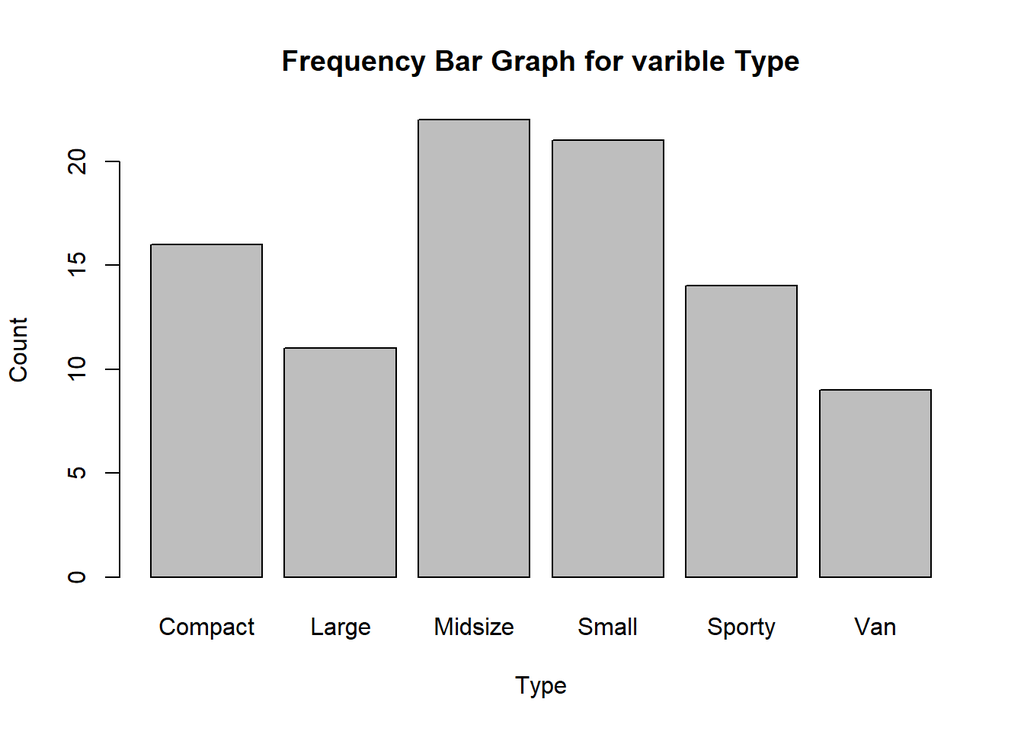

```r
frequency_table <- table(Cars93$Type)
barplot(frequency_table, ylab = "Count", xlab = "Type", main = "Frequency Bar Graph for varible Type")
```

- Your axes should be labeled and legible
- The bars should be of different colors
- The plot should include a title using the main argument
- The names, labels, and axes sizes (cex parameter) should be set to 1.2
3. Create a pie chart of the variable `Type`.

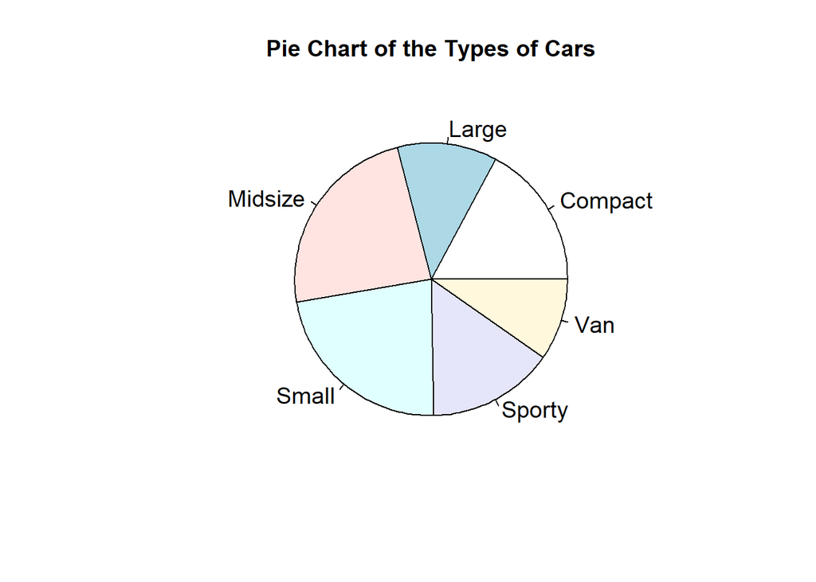

```r
frequency_table <- table(Cars93$Type)
pie(frequency_table,labels = names(frequency_table), cex = 1.2, main = "Pie Chart of the Types of Cars")
```

- The plot should include a title using the main argument.
- The names, labels, and axes sizes (cex parameter) should be set to 1.2
4. What is the mode of the variable `Type`? Comment. Answer: Midsized cars are the most frequent in the bar graph there for is the mode

## Task 2

1. Create a histogram of the variable `Horsepower`.

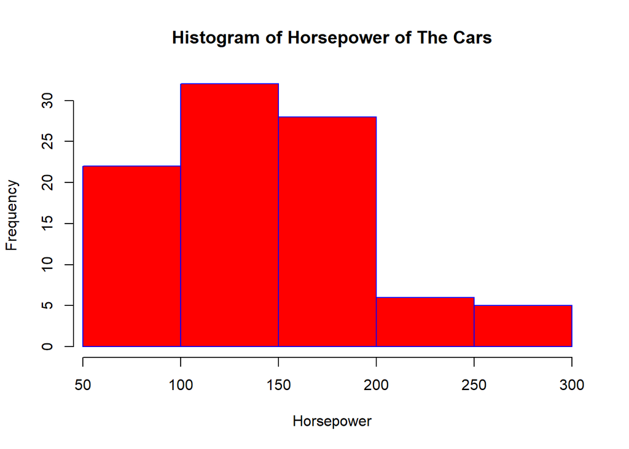

```r
hist(Cars93$Horsepower,main = "Histogram of Horsepower of The Cars",xlab="Horsepower",border="blue", col= "red", cex=1.2, xlim=c(min(Cars93$Horsepower), max(Cars93$Horsepower)))
```

- Your axes should be labeled
- The hist body should have a color (your choice, not too dark to obscure lines)
- The plot should include a title using the main argument
- The names, labels, and axes sizes should be set to 1.2
2. Create a second histogram with breaks at 25 HP increments instead of 50.

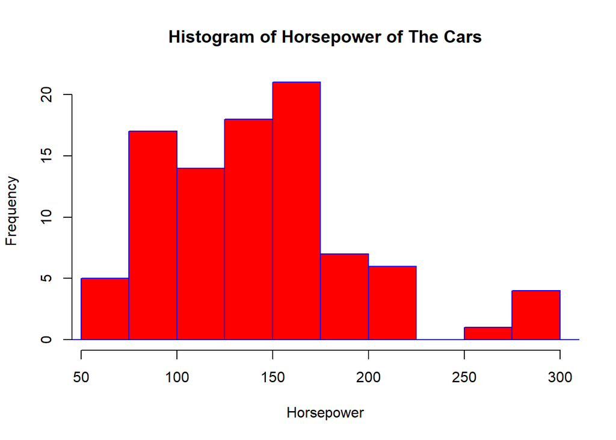

```r
hist(Cars93$Horsepower,breaks = seq(0,max(Cars93$Horsepower) + 25, by = 25), main = "Histogram of Horsepower of The Cars",xlab="Horsepower",border="blue", col= "red", cex=1.2, xlim=c(min(Cars93$Horsepower), max(Cars93$Horsepower)))
```

- Use the breaks argument to define the classes
- Other setting should be as in part (a)
3. Which histogram more closely follows or rule of thumb for the suggested number of classes? Explain. Answer: The second histrogram because it is more spread out and shows the distribution of the data better because in the first histogram the data is pushed together and not as spead out.

## Task 3

1. What is the type of variable `Passengers`? (Categorical nominal/ordinal or Numerical discrete/continuous?) What happens if we were to make a histogram for `Passengers`? What is the problem with this graph? Answer: The varible Passengers is a numerical discrete varible. When you create a histogram as you see below, the graph is suggesting the data is continous when it is not.

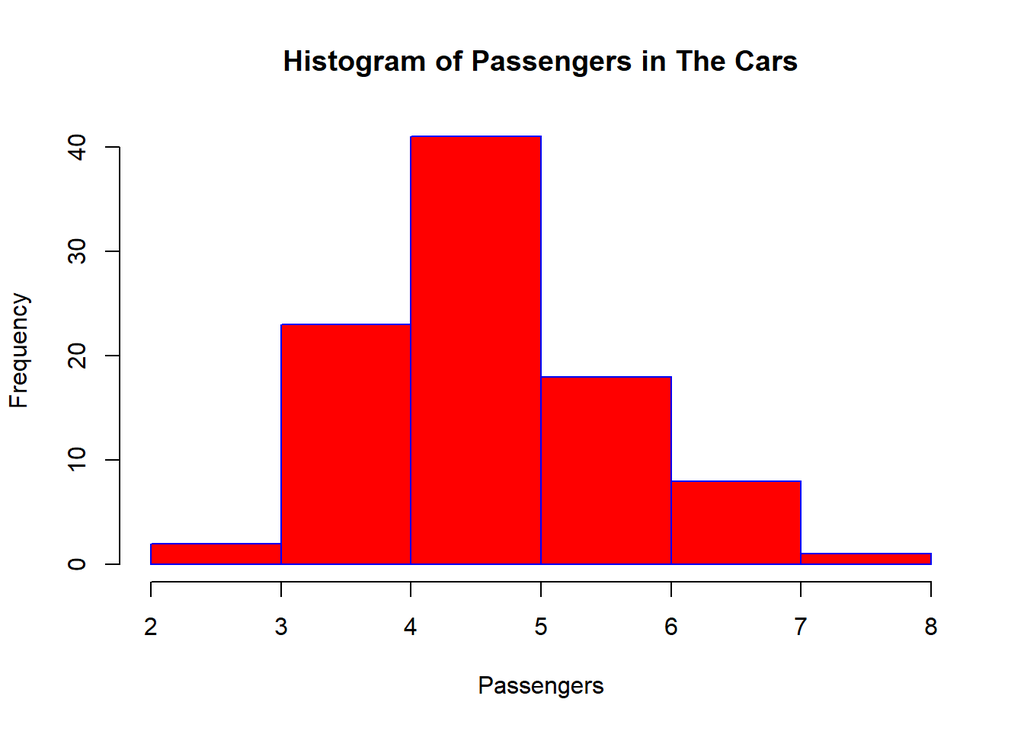

```r
hist(Cars93$Passengers,main = "Histogram of Passengers in The Cars",xlab="Passengers",border="blue", col= "red", cex=1.2, xlim=c(min(Cars93$Passengers), max(Cars93$Passengers)))
```

2. Correct the problem in part (a) by creating a more appropriate visualization. Make sure to label your axes, place a title, choose a custom color as in the previous graphs. (Bonus: use factor() with levels option to display x axis values with no observations on the plot.)

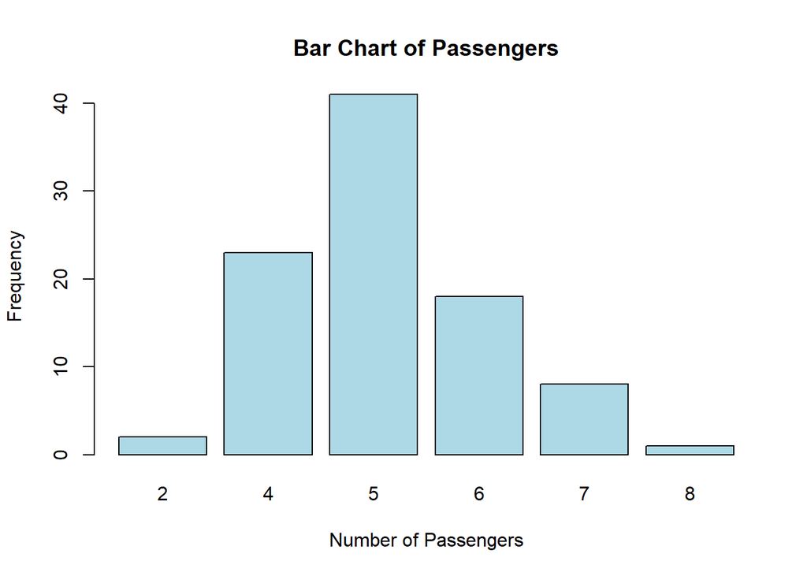

```r
passenger_frequency<- table(Cars93$Passengers)
barplot(passenger_frequency, main = "Bar Chart of Passengers", xlab= "Number of Passengers", ylab="Frequency", col="lightblue", border= "black")
```

## Task 4

1. Make a histogram of the variable `Length` (the default breaks are fine). Other aspects of the plot should be as in part (a) in Task 2.

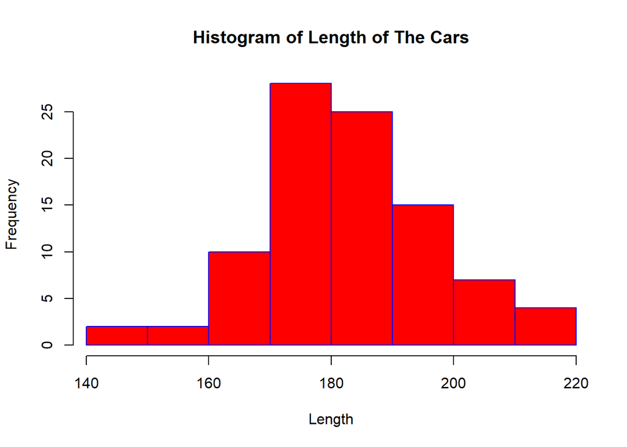

```r
hist(Cars93$Length,main = "Histogram of Length of The Cars",xlab="Length",border="blue", col= "red", cex=1.2, xlim=c(min(Cars93$Length), max(Cars93$Length)))
```

```r
mean(Cars93$Length)
```

```
## [1] 183.2043
```

```r
median(Cars93$Length)
```

```
## [1] 183
```

You are done! 🏁 Don’t forget to commit and push your .Rmd file to your Github repository before the due date.